# EDA Adverse Food Events

Bukun

# 1 Introduction

The CFSAN Adverse Event Reporting System (CAERS) is a database that contains information on adverse event and product complaint reports submitted to FDA for foods, dietary supplements, and cosmetics. The database is designed to support CFSAN’s safety surveillance program.

We explore the data as outlined in the Table Of Contents.

We should **NOT eat the following products since they cause DEATH** :

- Raw Oysters
- Axon
- Benefiber with Wheat Dextrin
- 5 Hour Energy
- Shower to Shower Powder

**Diarrhoea , Vomiting , Nausea , Abdominal Pain** are the most common Symptoms. The products which cause these symptoms include the following

- Peanut Butter
- Raw Oysters
- MultiVitamin
- Vitamin D
- Fish Oil

**Avoid** the following since it causes Adverse Events

- Certain Cleansing Conditioners such as Wen Cleansing Conditioner
- Vitamin D
- Certain Weight loss products such as Hydroxycut

We find that **Females** report Adverse Events more than **Males**.

There is a **distinct difference** in the products which cause adverse events for Females and Males. The products which cause the adverse events in Females are different kind of **Vitamins , Cleansing Conditioner**. The products which cause the adverse events in Males are **Super Beta Prostate , Hydroxy Cut ( a weight loss product ) , Raw Oysters , Peanut Butter**.

An analyst’s guidance : We should be very careful in choosing **Cosmetics** and **Artificial Supplements**

Please **upvote** if you like it.

# 2 Read the Data

```r
library(tidyverse)
library(stringr)
library(lubridate)
library(DT)
library(knitr)
library(kableExtra)



rm(list=ls())

fillColor = "#FFA07A"
fillColor2 = "#F1C40F"

AdverseFoodEvents = read_csv("../input/CAERS_ASCII_2004_2017Q2.csv")
```

# 3 Peek into the Data

```r
kable(head(AdverseFoodEvents),"html") %>%
  kable_styling(bootstrap_options = c("striped", "hover", "condensed", "responsive")) %>%
  scroll_box(width = "800px")
```

| RA_Report # | RA_CAERS Created Date | AEC_Event Start Date | PRI_Product Role | PRI_Reported Brand/Product Name | PRI_FDA Industry Code | PRI_FDA Industry Name | CI_Age at Adverse Event | CI_Age Unit | CI_Gender | AEC_One Row Outcomes | SYM_One Row Coded Symptoms |
| --- | --- | --- | --- | --- | --- | --- | --- | --- | --- | --- | --- |
| 65325 | 1/1/2004 | 8/4/2003 | Suspect | MIDWEST COUNTRY FAIR CHOCOLATE FLAVORED CHIPS | 3 | Bakery Prod/Dough/Mix/Icing | 2 | Year(s) | Female | VISITED AN ER, VISITED A HEALTH CARE PROVIDER, REQ. INTERVENTION TO PRVNT PERM. IMPRMNT., HOSPITALIZATION | SWELLING FACE, RASH, WHEEZING, COUGH, HOSPITALISATION, DYSPNOEA |
| 65325 | 1/1/2004 | 8/4/2003 | Suspect | MIDWEST COUNTRY FAIR CHOCOLATE FLAVORED CHIPS | 3 | Bakery Prod/Dough/Mix/Icing | 2 | Year(s) | Female | VISITED AN ER, VISITED A HEALTH CARE PROVIDER, REQ. INTERVENTION TO PRVNT PERM. IMPRMNT., HOSPITALIZATION | SWELLING FACE, WHEEZING, COUGH, RASH, HOSPITALISATION, DYSPNOEA |
| 65333 | 1/1/2004 | NA | Suspect | KROGER CLASSIC CREAM-DE-MINT CANDY MINT CHIP ICE CREAM | 13 | Ice Cream Prod | NA | Not Available | Female | VISITED AN ER | NAUSEA, DYSGEUSIA, DIARRHOEA |
| 65335 | 1/1/2004 | 11/24/2003 | Suspect | ENFAMIL LIPIL BABY FORMULA | 40 | Baby Food Prod | 3 | Month(s) | Not Available | NON-SERIOUS INJURIES/ ILLNESS | GASTROINTESTINAL DISORDER, VOMITING |
| 65336 | 1/1/2004 | NA | Suspect | ENFIMIL LIPIL BABY FORMULA | 40 | Baby Food Prod | NA | Not Available | Not Available | VISITED A HEALTH CARE PROVIDER | GASTROINTESTINAL DISORDER, PHYSICAL EXAMINATION |
| 65345 | 1/1/2004 | 12/21/2003 | Suspect | FRITO LAY FUNYUNS ONION FLAVOR, ONION RINGS | 7 | Snack Food Item | 10 | Year(s) | Male | NON-SERIOUS INJURIES/ ILLNESS | CHOKING |

# 4 Rename Fields

The field names are not user friendly. Let us **rename** the fields to user friendly names.

```r
AdverseFoodEvents = AdverseFoodEvents %>%
  rename(ReportNo = `RA_Report #`) %>%
  rename(CreatedDate = `RA_CAERS Created Date`) %>%
  rename(StartDate = `AEC_Event Start Date`) %>%
  rename(ProductRole = `PRI_Product Role`) %>%
  rename(ProductName = `PRI_Reported Brand/Product Name`) %>%
  rename(IndustryName = `PRI_FDA Industry Name`) %>%
  rename(AgeUnit = `CI_Age Unit`) %>%
  rename(AgeAtAdverseEvent = `CI_Age at Adverse Event`) %>%
  rename(Gender = `CI_Gender`) %>%
  rename(Outcomes = `AEC_One Row Outcomes`) %>%
  rename(Symptoms = `SYM_One Row Coded Symptoms`)

colnames(AdverseFoodEvents)
```

```
##  [1] "ReportNo"              "CreatedDate"
##  [3] "StartDate"             "ProductRole"
##  [5] "ProductName"           "PRI_FDA Industry Code"
##  [7] "IndustryName"          "AgeAtAdverseEvent"
##  [9] "AgeUnit"               "Gender"
## [11] "Outcomes"              "Symptoms"
```

# 5 Ten Most Common Symptoms

We examine the **Top Most Common Symptoms** associated with the Adverse Events and plot them in the bar plot.

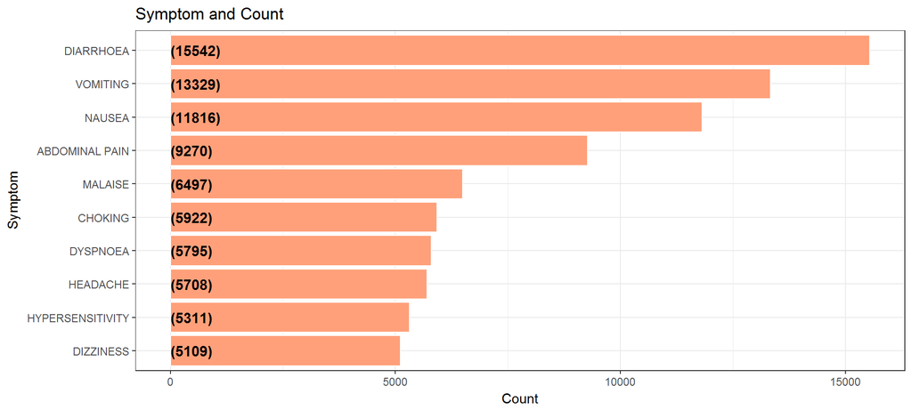

```r
BarPlotSymptoms = function(AdverseFoodEvents)
{
  Symptoms = str_split(AdverseFoodEvents$Symptoms,',')

AllSymptoms <- data.frame(matrix(unlist(Symptoms),byrow=T),stringsAsFactors=FALSE)

Symptoms = str_split(AdverseFoodEvents$Symptoms,',')

AllSymptoms <- data.frame(matrix(unlist(Symptoms),byrow=T),stringsAsFactors=FALSE)

colnames(AllSymptoms) = c("SymptomName")

#trimws returns a character string with leading and/or trailing whitespaces removed.
AllSymptoms$SymptomName = trimws(AllSymptoms$SymptomName)

AllSymptoms %>%
  group_by(SymptomName) %>%
  summarise(Count = n()) %>%
  arrange(desc(Count)) %>%
  ungroup() %>%
  mutate(SymptomName = reorder(SymptomName,Count)) %>%
  head(10) %>%

  ggplot(aes(x = SymptomName,y = Count)) +
  geom_bar(stat='identity',colour="white", fill = fillColor) +
  geom_text(aes(x = SymptomName, y = 1, label = paste0("(",Count,")",sep="")),
            hjust=0, vjust=.5, size = 4, colour = 'black',
            fontface = 'bold') +
  labs(x = 'Symptom',
       y = 'Count',
       title = 'Symptom and Count') +
  coord_flip() +
  theme_bw()
}

BarPlotSymptoms(AdverseFoodEvents)
```

# 6 Ten Most Common Product Name

We examine the **Top Most Common Products** associated with the Adverse Events and plot them in the bar plot.

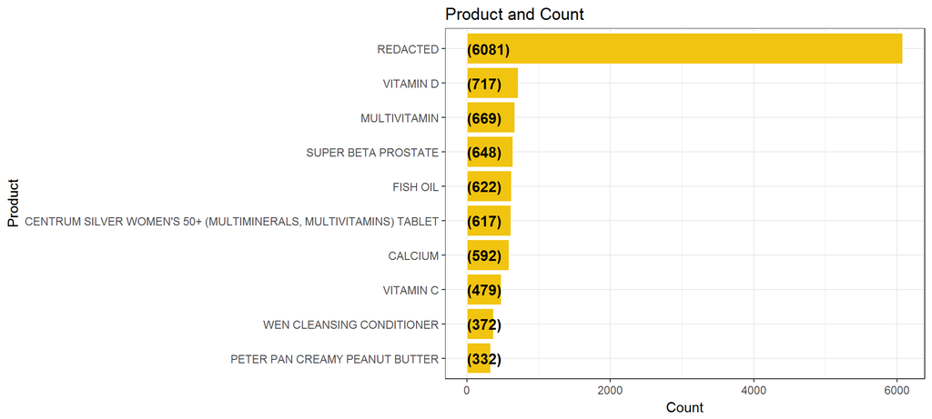

```r
AdverseFoodEvents %>%
  group_by(ProductName) %>%
  summarise(Count = n()) %>%
  arrange(desc(Count)) %>%
  ungroup() %>%
  mutate(ProductName = reorder(ProductName,Count)) %>%
  head(10) %>%

  ggplot(aes(x = ProductName,y = Count)) +
  geom_bar(stat='identity',colour="white", fill = fillColor2) +
  geom_text(aes(x = ProductName, y = 1, label = paste0("(",Count,")",sep="")),
            hjust=0, vjust=.5, size = 4, colour = 'black',
            fontface = 'bold') +
  labs(x = 'Product',
       y = 'Count',
       title = 'Product and Count') +
  coord_flip() +
  theme_bw()
```

# 7 Ten Most Common Industry Name

We examine the **Top Most Common Industries** associated with the Adverse Events and plot them in the bar plot.

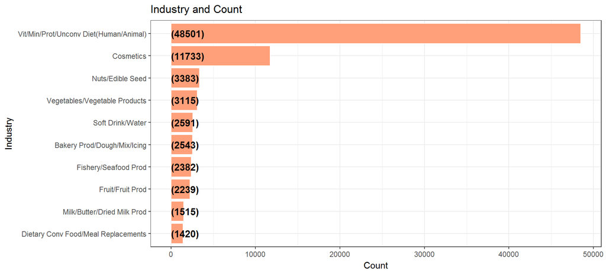

```r
AdverseFoodEvents %>%
  group_by(IndustryName) %>%
  summarise(Count = n()) %>%
  arrange(desc(Count)) %>%
  ungroup() %>%
  mutate(IndustryName = reorder(IndustryName,Count)) %>%
  head(10) %>%

  ggplot(aes(x = IndustryName,y = Count)) +
  geom_bar(stat='identity',colour="white", fill = fillColor) +
  geom_text(aes(x = IndustryName, y = 1, label = paste0("(",Count,")",sep="")),
            hjust=0, vjust=.5, size = 4, colour = 'black',
            fontface = 'bold') +
  labs(x = 'Industry',
       y = 'Count',
       title = 'Industry and Count') +
  coord_flip() +
  theme_bw()
```

# 8 Ages Commonly Affected

We examine the **Top Most Common Ages** associated with the Adverse Events and plot them in the bar plot.

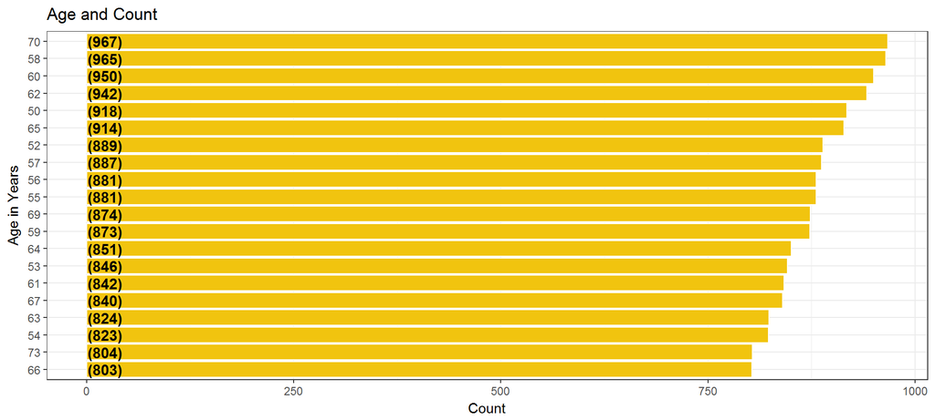

```r
TransformIntoYears = function(ds)
{
  if(!is.na(ds["AgeAtAdverseEvent"]))
  {
    x = as.numeric(ds["AgeAtAdverseEvent"])

    ds["AgeAtAdverseEvent"] = as.numeric(ds["AgeAtAdverseEvent"])

     if(ds["AgeUnit"] == "Month(s)")
    {
      ds["AgeAtAdverseEventInYears"] = x/12

    }
    else if (ds["AgeUnit"] == "Weeks(s)")
    {
      ds["AgeAtAdverseEventInYears"] = x*7/365
    }
    else if (ds["AgeUnit"] == "Day(s)")
    {
      ds["AgeAtAdverseEventInYears"] = x*1/365
    }
    else if (ds["AgeUnit"] == "Decade(s)")
    {
      ds["AgeAtAdverseEventInYears"] = x*10
    }
  }

  return(ds)
}

AdverseFoodEvents = AdverseFoodEvents %>%
  mutate(AgeAtAdverseEventInYears = AgeAtAdverseEvent)

AdverseFoodEvents$AgeAtAdverseEventInYears =
  as.numeric(AdverseFoodEvents$AgeAtAdverseEventInYears)

AdverseFoodEvents = sapply(AdverseFoodEvents,TransformIntoYears)

AdverseFoodEvents = as.data.frame(AdverseFoodEvents)

AdverseFoodEvents %>%
  filter(!is.na(AgeAtAdverseEventInYears)) %>%
  group_by(AgeAtAdverseEventInYears) %>%
  summarise(Count = n()) %>%
  arrange(desc(Count)) %>%
  ungroup() %>%
  mutate(AgeAtAdverseEventInYears = reorder(AgeAtAdverseEventInYears,Count)) %>%
  head(20) %>%

  ggplot(aes(x = AgeAtAdverseEventInYears,y = Count)) +
  geom_bar(stat='identity',colour="white", fill = fillColor2) +
  geom_text(aes(x = AgeAtAdverseEventInYears, y = 1, label = paste0("(",Count,")",sep="")),
            hjust=0, vjust=.5, size = 4, colour = 'black',
            fontface = 'bold') +
  labs(x = 'Age in Years',
       y = 'Count',
       title = 'Age and Count') +
  coord_flip() +
  theme_bw()
```

# 9 Distribution of Ages

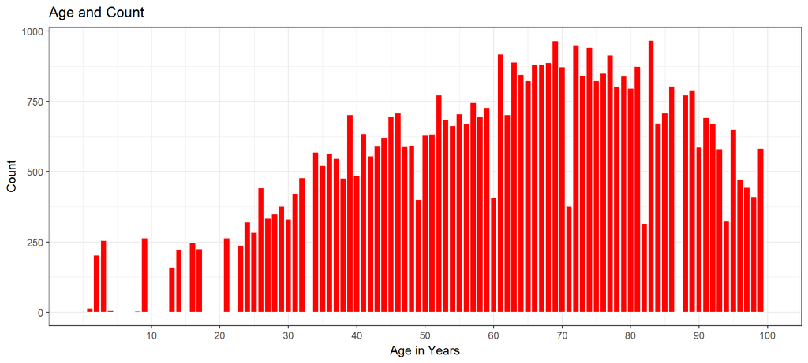

```r
breaks = c(10,20,30,40,50,60,70,80,90,100)

AdverseFoodEvents %>%
  filter(!is.na(AgeAtAdverseEventInYears)) %>%
  group_by(AgeAtAdverseEventInYears) %>%
  summarise(Count = n()) %>%
  ungroup() %>%
  mutate(AgeAtAdverseEventInYears = as.numeric(AgeAtAdverseEventInYears)) %>%

  ggplot(aes(x = AgeAtAdverseEventInYears,y = Count)) +
  geom_bar(stat='identity',colour="white", fill = c("red")) +
  scale_x_continuous(limits = c(0, 100),breaks=breaks ) +
  labs(x = 'Age in Years',
       y = 'Count',
       title = 'Age and Count') +

  theme_bw()
```

**Ages 50 onwards**, the number of adverse events rises.

```r
PlotProducts = function(ds,fillColorName)
{
  ds %>%
  group_by(ProductName) %>%
  summarise(Count = n()) %>%
  arrange(desc(Count)) %>%
  ungroup() %>%
  mutate(ProductName = reorder(ProductName,Count)) %>%
  head(10) %>%

  ggplot(aes(x = ProductName,y = Count)) +
  geom_bar(stat='identity',colour="white", fill = c(fillColorName)) +
  geom_text(aes(x = ProductName, y = 1, label = paste0("(",Count,")",sep="")),
            hjust=0, vjust=.5, size = 4, colour = 'black',
            fontface = 'bold') +
  labs(x = 'Products',
       y = 'Count',
       title = 'Products') +
  coord_flip() +
  theme_bw()

}
```

We examine the **Products** which cause Adverse Events for the following age groups

- 70 and Above
- 60 to 69
- 50 to 59
- Less than 5

## 9.1 70 and Above Adverse Products

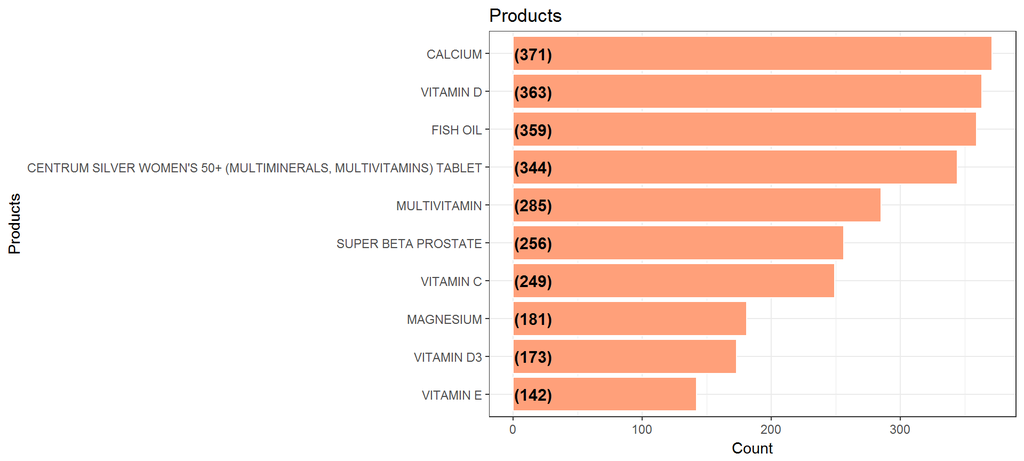

```r
AdverseFoodEvents %>%
  mutate(AgeAtAdverseEventInYears = as.integer(AgeAtAdverseEventInYears)) %>%
  filter(AgeAtAdverseEventInYears >=70) %>%
  filter(ProductName != "REDACTED") %>%
  PlotProducts(fillColorName = fillColor)
```

## 9.2 Age 60 - 69 Adverse Products

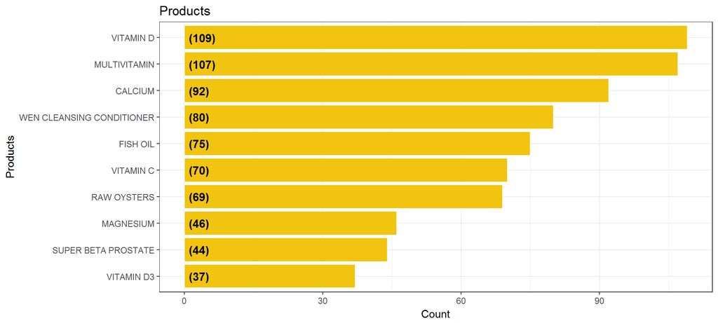

```r
AdverseFoodEvents %>%
  mutate(AgeAtAdverseEventInYears = as.integer(AgeAtAdverseEventInYears)) %>%
  filter(AgeAtAdverseEventInYears <70) %>%
  filter(AgeAtAdverseEventInYears >=60) %>%
  filter(ProductName != "REDACTED") %>%
  PlotProducts(fillColorName = fillColor2)
```

## 9.3 Age 50 - 59 Adverse Products

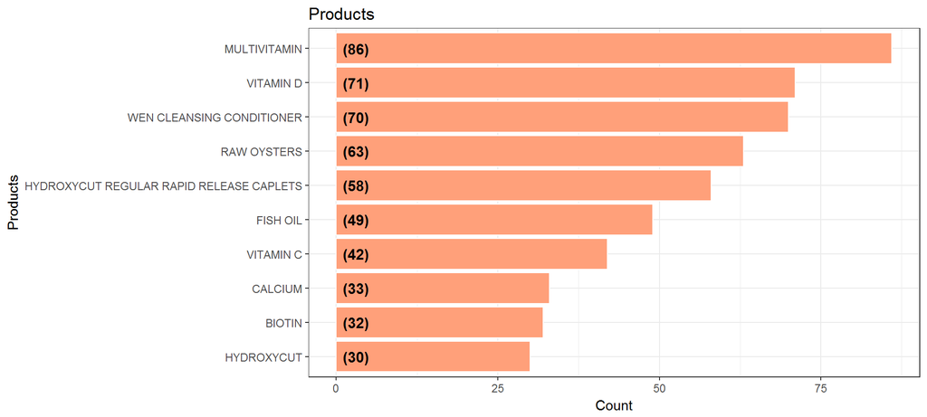

```r
AdverseFoodEvents %>%
  mutate(AgeAtAdverseEventInYears = as.integer(AgeAtAdverseEventInYears)) %>%
  filter(AgeAtAdverseEventInYears <60) %>%
  filter(AgeAtAdverseEventInYears >=50) %>%
  filter(ProductName != "REDACTED") %>%
  PlotProducts(fillColorName = fillColor)
```

## 9.4 Less than 5 Adverse Products

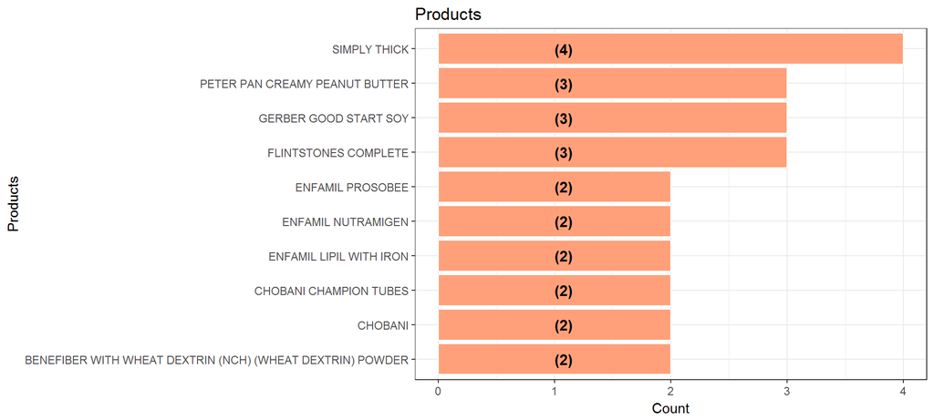

```r
AdverseFoodEvents %>%
  mutate(AgeAtAdverseEventInYears = as.numeric(AgeAtAdverseEventInYears)) %>%
  filter(AgeAtAdverseEventInYears < 5) %>%
  filter(ProductName != "REDACTED") %>%
  PlotProducts(fillColorName = fillColor)
```

# 10 Ten Most Common Outcomes

We examine the Top Most Common **Outcomes** associated with the Adverse Events and plot them in the bar plot.

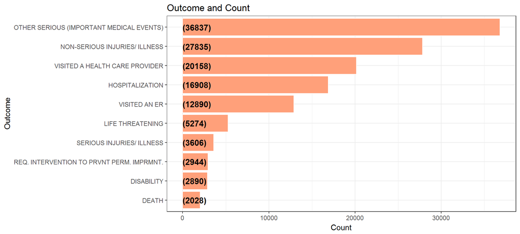

```r
Outcomes = str_split(AdverseFoodEvents$Outcomes,',')

AllOutcomes <- data.frame(matrix(unlist(Outcomes),byrow=T),stringsAsFactors=FALSE)

colnames(AllOutcomes) = c("OutcomeName")

#trimws returns a character string with leading and/or trailing whitespaces removed.

AllOutcomes$OutcomeName = trimws(AllOutcomes$OutcomeName)

AllOutcomes %>%
  group_by(OutcomeName) %>%
  summarise(Count = n()) %>%
  arrange(desc(Count)) %>%
  ungroup() %>%
  mutate(OutcomeName = reorder(OutcomeName,Count)) %>%
  head(10) %>%

  ggplot(aes(x = OutcomeName,y = Count)) +
  geom_bar(stat='identity',colour="white", fill = fillColor) +
  geom_text(aes(x = OutcomeName, y = 1, label = paste0("(",Count,")",sep="")),
            hjust=0, vjust=.5, size = 4, colour = 'black',
            fontface = 'bold') +
  labs(x = 'Outcome',
       y = 'Count',
       title = 'Outcome and Count') +
  coord_flip() +
  theme_bw()
```

# 11 Outcomes and Products associated with Adverse Events

We examine the **Products** associated with the following outcomes

- Death
- Death for persons 70 and above
- Disability

We find causes of deaths to be primarily caused by

- Raw Oysters
- Axon
- Benefiber with Wheat Dextrin
- 5 Hour Energy
- Shower to Shower Powder

## 11.1 Death Products

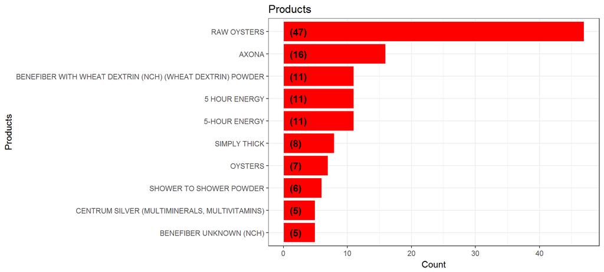

```r
keywordOutcome = "DEATH"

OutcomeSpecificEvents = AdverseFoodEvents %>%
  filter(str_detect(Outcomes,keywordOutcome))

OutcomeSpecificEvents %>%
  filter(ProductName != "REDACTED") %>%
  PlotProducts(fillColorName = "red")
```

Why would someone eat **Raw Oysters** ?

## 11.2 Death Products for Age 70 and Above

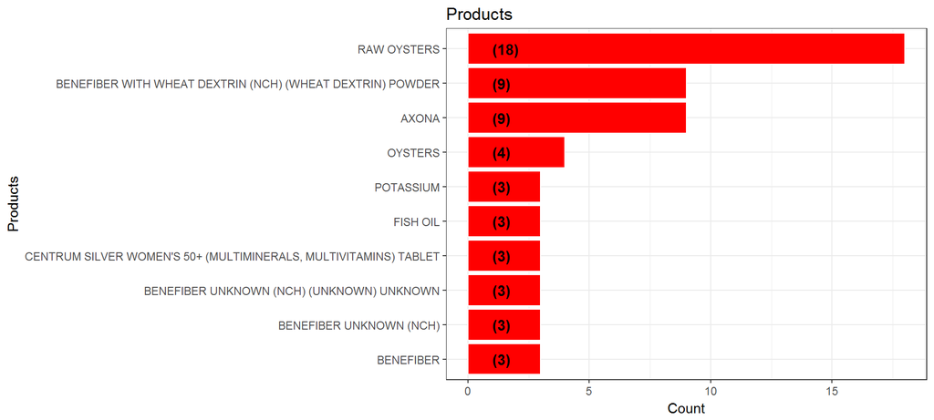

```r
keywordOutcome = "DEATH"

OutcomeSpecificEvents = AdverseFoodEvents %>%
  filter(str_detect(Outcomes,keywordOutcome))

OutcomeSpecificEvents %>%
  mutate(AgeAtAdverseEventInYears = as.integer(AgeAtAdverseEventInYears)) %>%
  filter(AgeAtAdverseEventInYears >= 70) %>%
  filter(ProductName != "REDACTED") %>%
  PlotProducts(fillColorName = "red")
```

## 11.3 Disability Products

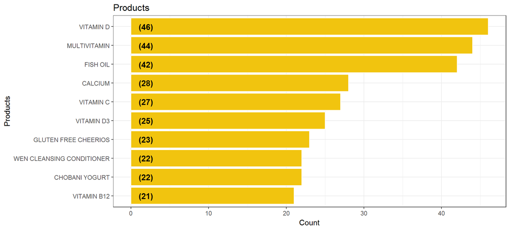

```r
keywordOutcome = "DISABILITY"

OutcomeSpecificEvents = AdverseFoodEvents %>%
  filter(str_detect(Outcomes,keywordOutcome))

OutcomeSpecificEvents %>%
  PlotProducts(fillColorName = fillColor2)
```

# 12 Symptoms and the Products Causing it

We examine the **Products** associated with the **Symptoms** and plot them in a bar plot. We choose the Symptoms such as Diarrhoea, Vomiting and Dizziness to investigate the products.

```r
SymptomPlots = function(keywordSymptom,fillColorName = fillColor)
{
  AdverseFoodEvents %>%
  filter(str_detect(Symptoms,keywordSymptom)) %>%
  PlotProducts(fillColorName = fillColorName)

}
```

## 12.1 Diarrhoea

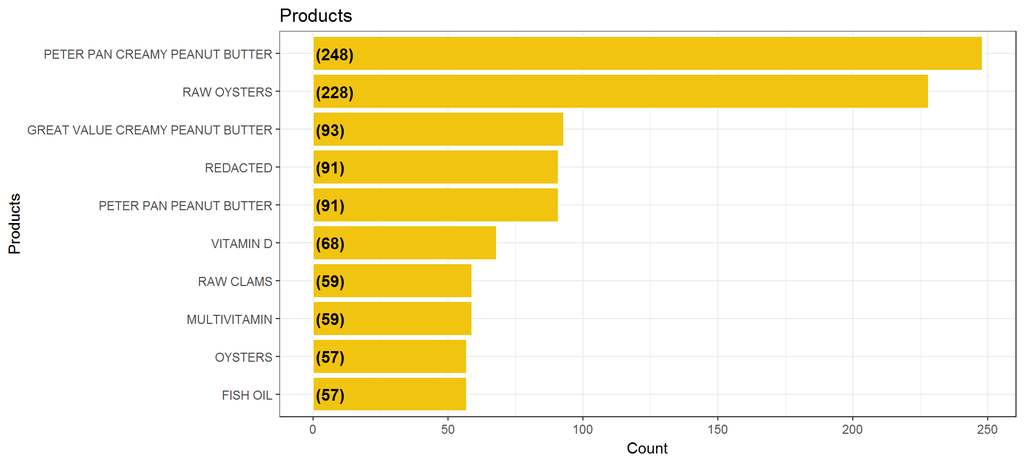

```r
keywordSymptom="DIARRHOEA"

SymptomPlots(keywordSymptom,fillColor2)
```

## 12.2 Vomiting

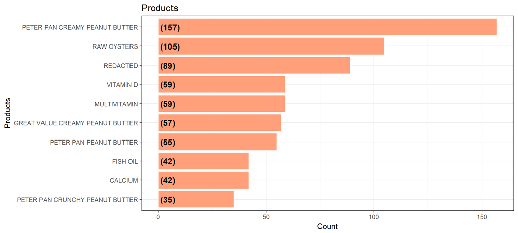

```r
keywordSymptom="VOMITING"

SymptomPlots(keywordSymptom)
```

## 12.3 Abdominal Pain

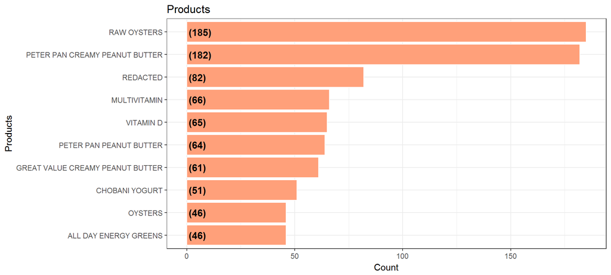

```r
keywordSymptom="ABDOMINAL PAIN"

SymptomPlots(keywordSymptom)
```

## 12.4 Dizziness

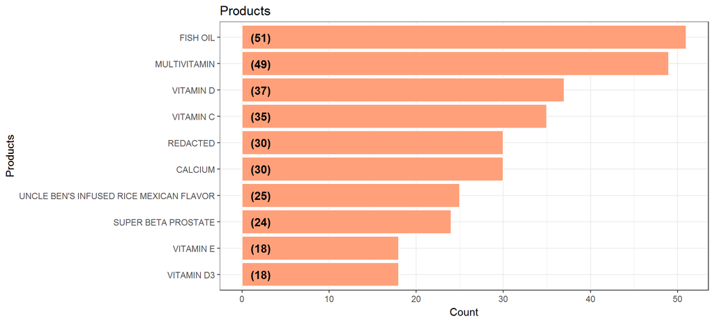

```r
keywordSymptom="DIZZINESS"

SymptomPlots(keywordSymptom)
```

# 13 Time Analysis of Adverse Events

## 13.1 Year wise

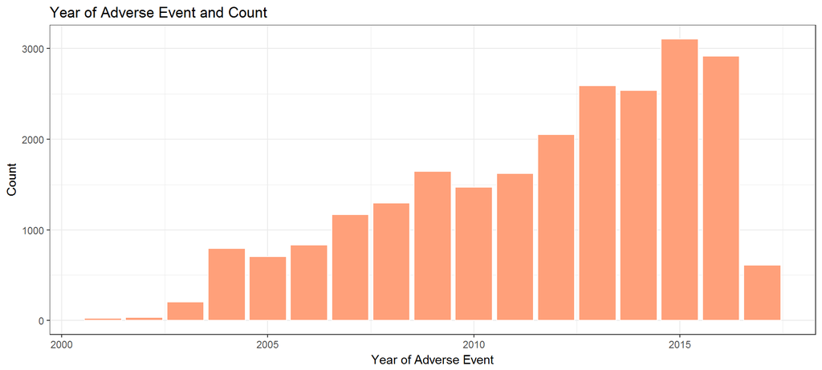

```r
AdverseFoodEvents %>%
  mutate(YearAdverseEvent = year(dmy(StartDate))) %>%
  filter(!is.na(YearAdverseEvent)) %>%
  filter(YearAdverseEvent > 2000) %>%
  group_by(YearAdverseEvent) %>%
  summarise(Count = n()) %>%
  arrange(YearAdverseEvent) %>%
  ungroup() %>%


  ggplot(aes(x = YearAdverseEvent,y = Count)) +
  geom_bar(stat='identity',colour="white", fill = fillColor) +
  labs(x = 'Year of Adverse Event',
       y = 'Count',
       title = 'Year of Adverse Event and Count') +
  theme_bw()
```

## 13.2 Most Common Month for Adverse Events

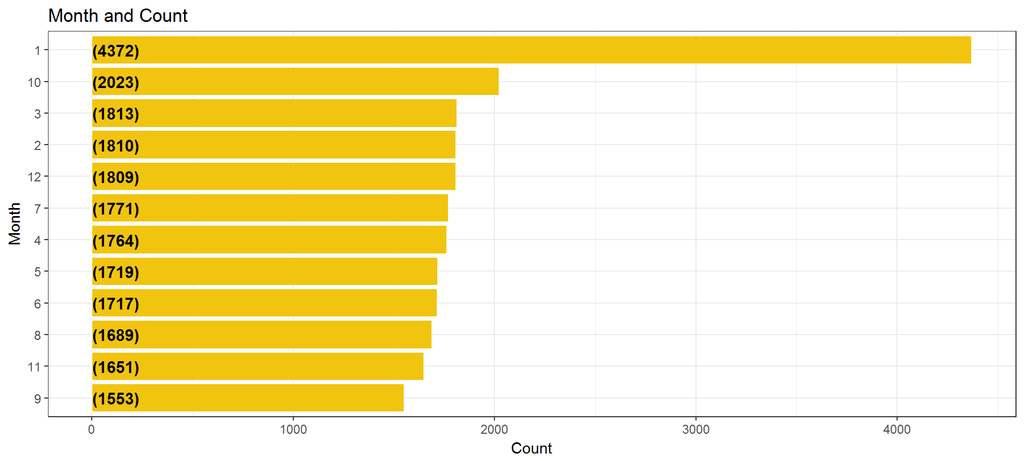

```r
AdverseFoodEvents %>%
  mutate(MonthAdverseEvent = month(dmy(StartDate))) %>%
  filter(!is.na(MonthAdverseEvent)) %>%
  group_by(MonthAdverseEvent) %>%
  summarise(Count = n()) %>%
  arrange(desc(Count)) %>%
  ungroup() %>%
  mutate(MonthAdverseEvent = reorder(MonthAdverseEvent,Count)) %>%


  ggplot(aes(x = MonthAdverseEvent,y = Count)) +
  geom_bar(stat='identity',colour="white", fill = fillColor2) +
  geom_text(aes(x = MonthAdverseEvent, y = 1, label = paste0("(",Count,")",sep="")),
            hjust=0, vjust=.5, size = 4, colour = 'black',
            fontface = 'bold') +
  labs(x = 'Month',
       y = 'Count',
       title = 'Month and Count') +
  coord_flip() +
  theme_bw()
```

# 14 Products in Adverse Events for January

We investigate the month of **January** since this accounts for the largest number of adverse events.

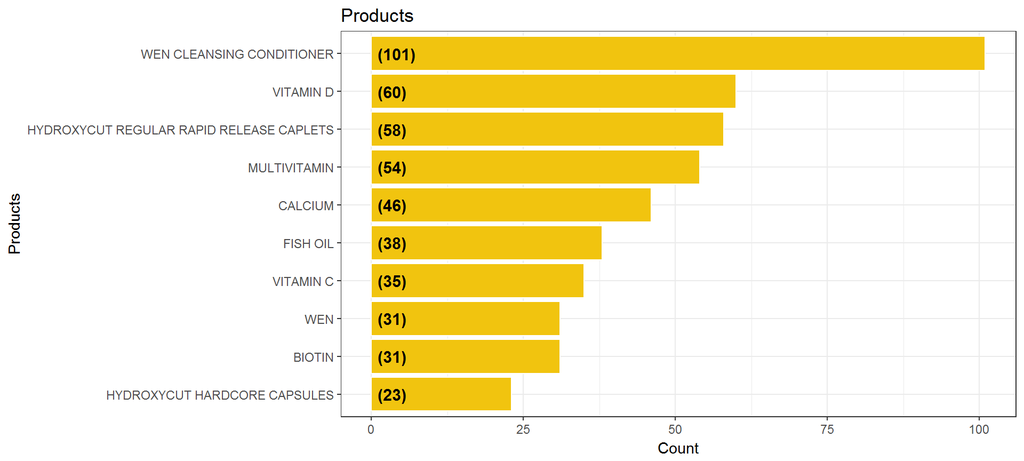

```r
AdverseFoodEvents %>%
  mutate(MonthAdverseEvent = month(dmy(StartDate))) %>%
  filter(MonthAdverseEvent == 1) %>%
  filter(ProductName != "REDACTED") %>%
  PlotProducts(fillColorName = fillColor2)
```

We find that **Wen Cleansing Conditioner** is the product which caused the maximum number of adverse events.

```r
PlotSymptoms = function(ds, fillColorName = fillColor)
{
  Symptoms = str_split(ds$Symptoms,',')

AllSymptoms <- data.frame(matrix(unlist(Symptoms),byrow=T),stringsAsFactors=FALSE)

colnames(AllSymptoms) = c("SymptomName")

#trimws returns a character string with leading and/or trailing whitespaces removed.
AllSymptoms$SymptomName = trimws(AllSymptoms$SymptomName)

AllSymptoms %>%
  group_by(SymptomName) %>%
  summarise(Count = n()) %>%
  arrange(desc(Count)) %>%
  ungroup() %>%
  mutate(SymptomName = reorder(SymptomName,Count)) %>%
  head(10) %>%

  ggplot(aes(x = SymptomName,y = Count)) +
  geom_bar(stat='identity',colour="white", fill = fillColorName) +
  geom_text(aes(x = SymptomName, y = 1, label = paste0("(",Count,")",sep="")),
            hjust=0, vjust=.5, size = 4, colour = 'black',
            fontface = 'bold') +
  labs(x = 'Symptom',
       y = 'Count',
       title = 'Symptom and Count') +
  coord_flip() +
  theme_bw()

}
```

## 14.1 Wen Cleansing Conditioner Symptoms

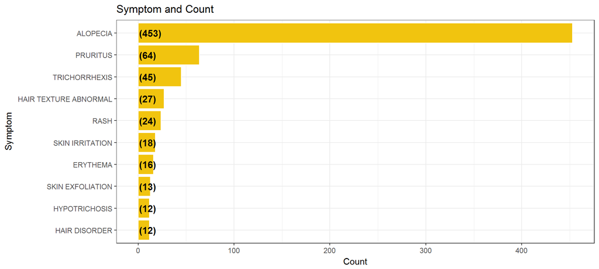

```r
WenEvents = AdverseFoodEvents %>%
  filter(ProductName == 'WEN CLEANSING CONDITIONER')

PlotSymptoms(WenEvents,fillColorName =  fillColor2)
```

## 14.2 Vitamin D Symptoms

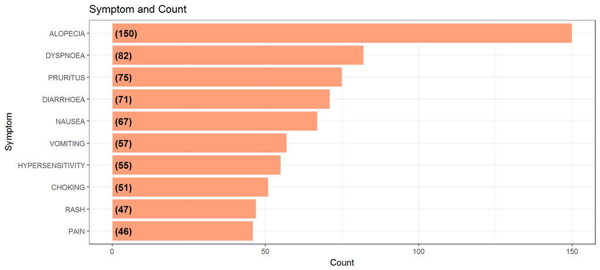

```r
VitDEvents = AdverseFoodEvents %>%
  filter(ProductName == 'VITAMIN D')

PlotSymptoms(VitDEvents,fillColorName =  fillColor)
```

## 14.3 Hydroxycut Symptoms

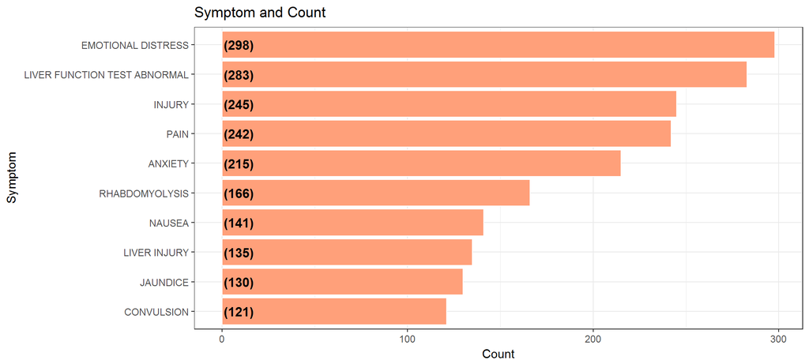

```r
HydroxycutEvents = AdverseFoodEvents %>%
  filter(str_detect(ProductName,'HYDROXYCUT'))

PlotSymptoms(HydroxycutEvents,fillColorName =  fillColor)
```

## 14.4 MultiVitamin Symptoms

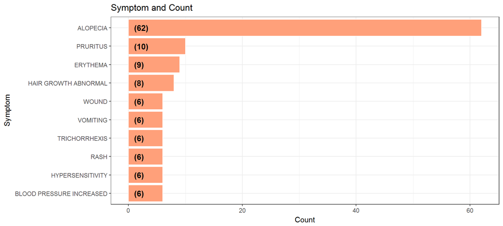

```r
VitDEvents = AdverseFoodEvents %>%
  filter(ProductName == 'MULTI VITAMIN')

PlotSymptoms(VitDEvents,fillColorName =  fillColor)
```

## 14.5 Fish Oil Symptoms

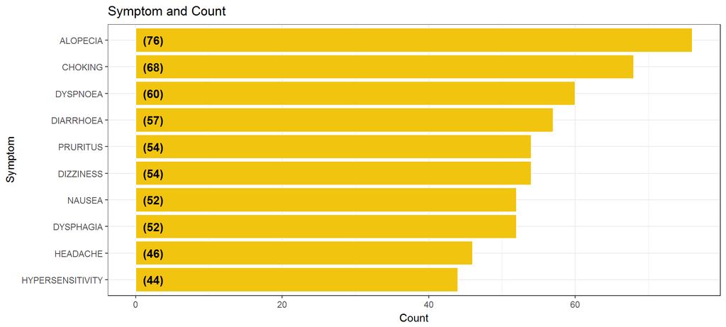

```r
ProductEvents = AdverseFoodEvents %>%
  filter(ProductName == 'FISH OIL')

PlotSymptoms(ProductEvents,fillColorName =  fillColor2)
```

# 15 Gender and Adverse Events

We find that **Females** report Adverse Events more than **Males**.

There is a **distinct difference** in the products which cause adverse events for Femeales and Males. The products which cause the adverse events in Females are different kind of **Vitamins , Cleansing Conditioner**. The products which cause the adverse events in Males are **Super Beta Prostate , Hydroxy Cut ( a weight loss product ) , Raw Oysters , Peanut Butter**.

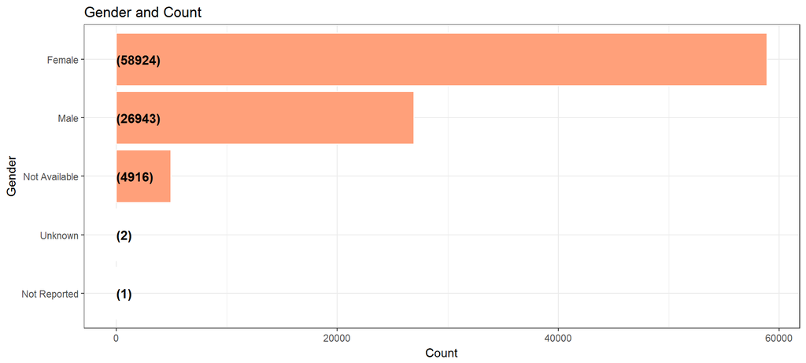

```r
AdverseFoodEvents %>%
  group_by(Gender) %>%
  filter(!is.na(Gender)) %>%
  summarise(Count = n()) %>%
  arrange(desc(Count)) %>%
  ungroup() %>%
  mutate(Gender = reorder(Gender,Count)) %>%
  head(10) %>%

  ggplot(aes(x = Gender,y = Count)) +
  geom_bar(stat='identity',colour="white", fill = fillColor) +
  geom_text(aes(x = Gender, y = 1, label = paste0("(",Count,")",sep="")),
            hjust=0, vjust=.5, size = 4, colour = 'black',
            fontface = 'bold') +
  labs(x = 'Gender',
       y = 'Count',
       title = 'Gender and Count') +
  coord_flip() +
  theme_bw()
```

Please see the bar charts below to see the differences in the **Products** used by the different sexes which lead to adverse events.

## 15.1 Plot Products for Female

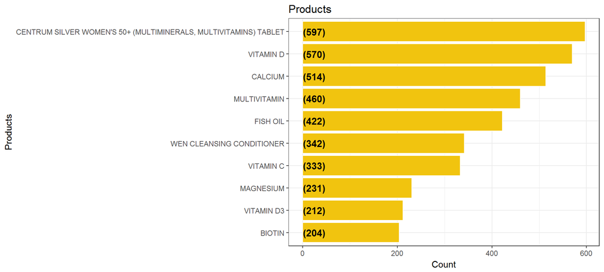

```r
AdverseFoodEvents %>%
  filter(Gender == 'Female') %>%
  filter(ProductName != "REDACTED") %>%
  PlotProducts(fillColorName = fillColor2)
```

## 15.2 Plot Products for Male

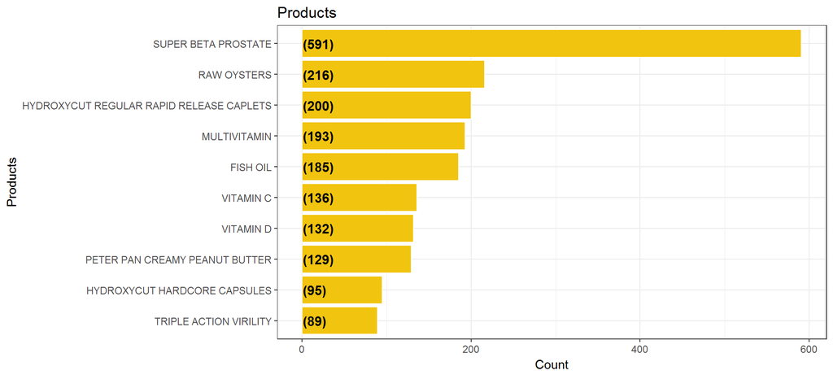

```r
AdverseFoodEvents %>%
  filter(Gender == 'Male') %>%
  filter(ProductName != "REDACTED") %>%
  PlotProducts(fillColorName = fillColor2)
```

## 15.3 Female Symptoms Top 10

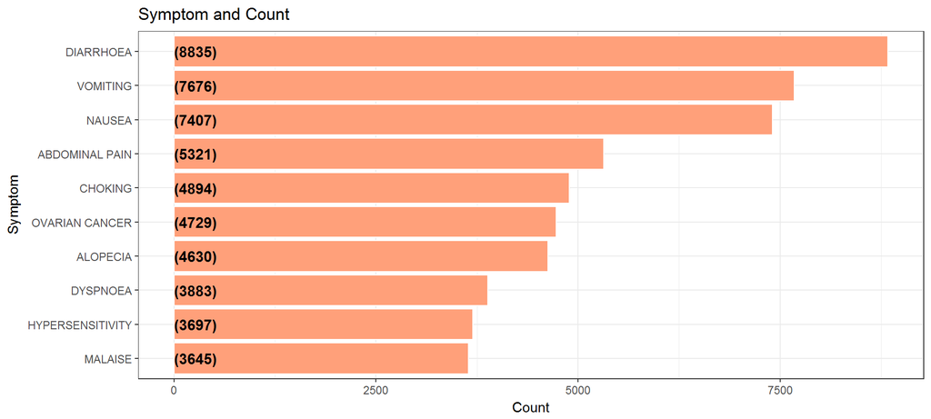

```r
AdverseFoodEvents %>%
  filter(Gender == 'Female') %>%
  BarPlotSymptoms()
```

## 15.4 Male Symptoms Top 10

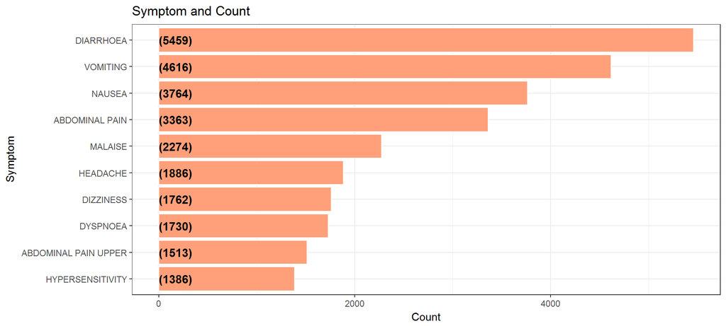

```r
AdverseFoodEvents %>%
  filter(Gender == 'Male') %>%
  BarPlotSymptoms()
```